# Can we predict a font's optical size from its shape?

**The question.** Given an arbitrary static font, can we measure its glyphs and output a sensible `opsz` value — the axis that distinguishes display, text, and caption cuts? If yes, we could auto-categorise the static fonts in Google Fonts without a human in the loop.

**The hope.** Display cuts have thinner thins, higher contrast, and smaller relative x-heights than text cuts. These are measurable. If the signal is consistent across designers, we can fit a model.

**The corpus.** Every variable font in `google/fonts/ofl` that ships an `opsz` axis — 42 fonts, 27 families. For each, we sampled 7 points across its `opsz` range and ran fontquant to extract ~20 parametric measurements at each point.

```python
import pandas as pd
import numpy as np
import matplotlib.pyplot as plt
import seaborn as sns
from pathlib import Path

sns.set_style("whitegrid")
plt.rcParams["figure.dpi"] = 100

CSV = Path.home() / "Type/opsz_research/measurements.csv"
df = pd.read_csv(CSV)
df.head()
```

|  | font | family_dir | is_italic | location | axis_opsz | axis_wght | XOFI | XOLC | XOPQ | XTFI | ... | descender | lowercase_a_style | lowercase_g_style | slant | stencil | stroke_contrast_angle | stroke_contrast_ratio | weight | width | x_height |
| --- | --- | --- | --- | --- | --- | --- | --- | --- | --- | --- | --- | --- | --- | --- | --- | --- | --- | --- | --- | --- | --- |
| 0 | Ballet[opsz].ttf | ballet | False | opsz=16.0 | 16.00 | NaN | 20 | 41 | 17 | 219 | ... | -532.0 | double_story | double_story | 0.554 | False | -59.15 | 0.01 | 0.140 | 0.712 | 316.000 |
| 1 | Ballet[opsz].ttf | ballet | False | opsz=25.33 | 25.33 | NaN | 19 | 40 | 15 | 211 | ... | -530.5 | double_story | double_story | 0.553 | False | -58.27 | 0.01 | 0.135 | 0.703 | 303.836 |
| 2 | Ballet[opsz].ttf | ballet | False | opsz=34.67 | 34.67 | NaN | 13 | 39 | 14 | 202 | ... | -529.0 | double_story | double_story | 0.553 | False | -58.91 | 0.01 | 0.131 | 0.694 | 291.664 |
| 3 | Ballet[opsz].ttf | ballet | False | opsz=44.0 | 44.00 | NaN | 18 | 37 | 12 | 194 | ... | -527.5 | double_story | double_story | 0.553 | False | -58.91 | 0.01 | 0.126 | 0.685 | 279.500 |
| 4 | Ballet[opsz].ttf | ballet | False | opsz=53.33 | 53.33 | NaN | 17 | 36 | 11 | 185 | ... | -526.0 | double_story | double_story | 0.553 | False | -58.90 | 0.01 | 0.121 | 0.677 | 267.336 |

5 rows × 27 columns

## What we have to work with

308 rows: 42 fonts × ~7 sample points across each font's `opsz` range. Each row records the location and the measurements at that location.

```python
print(f"Families: {df['family_dir'].nunique()}")
print(f"Fonts: {df['font'].nunique()}")
print(f"Total measurements: {len(df)}\n")
print("opsz range per font:")
df.groupby("font")["axis_opsz"].agg(["min", "max"]).head(8)
```

```
Families: 27
Fonts: 42
Total measurements: 308

opsz range per font:
```

| font | min | max |
| --- | --- | --- |
| Ballet[opsz].ttf | 16.0 | 72.0 |
| BigShouldersInline[opsz,wght].ttf | 10.0 | 72.0 |
| BigShouldersStencil[opsz,wght].ttf | 10.0 | 72.0 |
| BigShoulders[opsz,wght].ttf | 10.0 | 72.0 |
| BodoniModa-Italic[opsz,wght].ttf | 6.0 | 96.0 |
| BodoniModaSC-Italic[opsz,wght].ttf | 6.0 | 96.0 |
| BodoniModaSC[opsz,wght].ttf | 6.0 | 96.0 |
| BodoniModa[opsz,wght].ttf | 6.0 | 96.0 |

## One font at a time

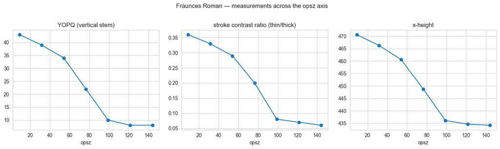

```python
fraunces = (df[(df["family_dir"] == "fraunces") & (~df["is_italic"])]
            .sort_values("axis_opsz"))

fig, axes = plt.subplots(1, 3, figsize=(14, 4))
for ax, metric, label in zip(
    axes,
    ["YOPQ", "stroke_contrast_ratio", "x_height"],
    ["YOPQ (vertical stem)", "stroke contrast ratio (thin/thick)", "x-height"],
):
    ax.plot(fraunces["axis_opsz"], fraunces[metric], "o-", color="C0")
    ax.set_xlabel("opsz")
    ax.set_title(label)
fig.suptitle("Fraunces Roman — measurements across the opsz axis", y=1.02)
plt.tight_layout()
plt.show()
```

Does every family agree? Let's overlay a few.

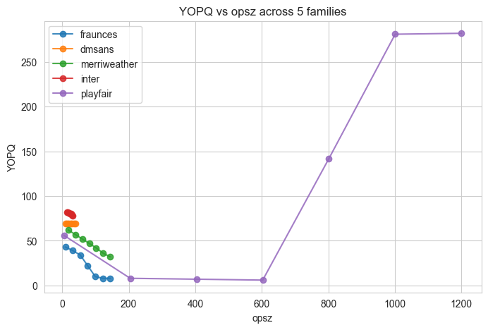

```python
families = ["fraunces", "dmsans", "merriweather", "inter", "playfair"]

fig, ax = plt.subplots(figsize=(8, 5))
for fam in families:
    g = df[(df["family_dir"] == fam) & (~df["is_italic"])].sort_values("axis_opsz")
    ax.plot(g["axis_opsz"], g["YOPQ"], "o-", label=fam, alpha=0.85)
ax.set_xlabel("opsz")
ax.set_ylabel("YOPQ")
ax.set_title("YOPQ vs opsz across 5 families")
ax.legend()
plt.show()
```

## Does it hold across the whole corpus?

For each (family, metric) pair, compute the Pearson correlation between the metric and `opsz`. A value near +1 or -1 means the metric tracks opsz tightly within that family; 0 means no relationship. Then summarise across all families.

```python
from scipy.stats import pearsonr

METRICS = [
    "YOPQ", "YOLC", "YOFI", "XOPQ", "XTRA", "XTLC",
    "stroke_contrast_ratio", "x_height", "cap_height", "weight", "width",
]

rows = []
for (family, italic), g in df.groupby(["family_dir", "is_italic"]):
    if g["axis_opsz"].nunique() < 3:
        continue
    for m in METRICS:
        s = pd.to_numeric(g[m], errors="coerce")
        if s.nunique() < 2 or s.isna().all():
            continue
        r, _ = pearsonr(g["axis_opsz"], s)
        rows.append({"family": family, "metric": m, "r": r})
corr = pd.DataFrame(rows)

summary = (corr.groupby("metric")
           .agg(median_r=("r", "median"),
                pct_families_strong=("r", lambda s: (s.abs() > 0.7).mean()),
                n_families=("family", "nunique"))
           .sort_values("median_r"))
summary.style.format({"median_r": "{:+.2f}", "pct_families_strong": "{:.0%}"})
```

| metric | median_r | pct_families_strong | n_families |
| --- | --- | --- | --- |
| YOPQ | -0.98 | 98% | 26 |
| XOPQ | -0.97 | 79% | 19 |
| YOFI | -0.97 | 89% | 24 |
| weight | -0.97 | 95% | 27 |
| width | -0.97 | 93% | 27 |
| YOLC | -0.96 | 92% | 25 |
| x_height | -0.95 | 77% | 16 |
| stroke_contrast_ratio | -0.92 | 97% | 24 |
| XTLC | -0.87 | 68% | 26 |
| XTRA | -0.82 | 86% | 23 |
| cap_height | +0.60 | 78% | 6 |

Read the table this way:

- **`median_r`** near ±1 means the metric moves in lockstep with opsz inside most families.
- **`pct_families_strong`** is the fraction of families where the correlation is strong (|r| > 0.7).

Six metrics (YOPQ, YOLC, YOFI, weight, width, stroke contrast) sit at `median_r` ≈ -0.95 with 90%+ of families showing a strong relationship. The signal is real.

Then there's **XTRA**: median ≈ -0.8 but with much higher variance. Let's look at why.

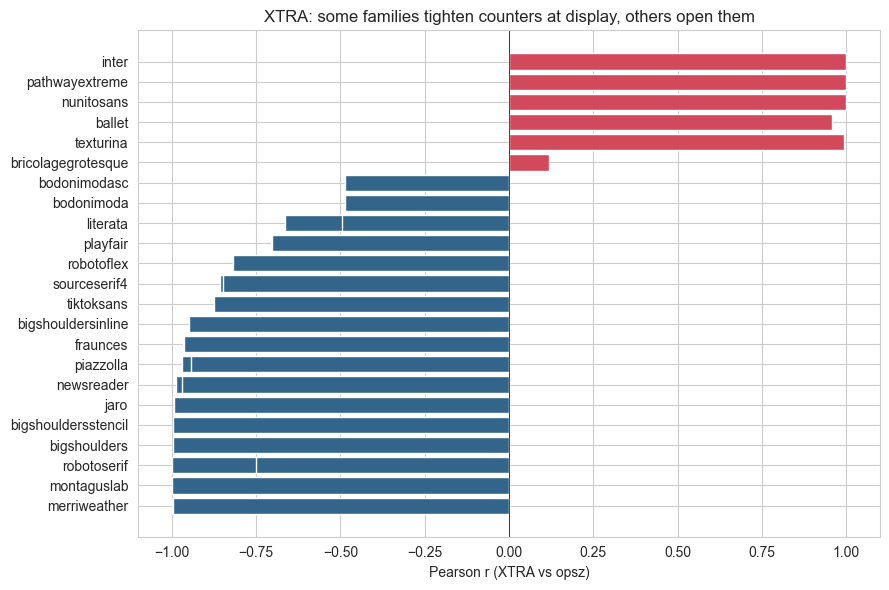

```python
xtra = corr[corr["metric"] == "XTRA"].sort_values("r")
colors = ["#d1495b" if r > 0 else "#33658a" for r in xtra["r"]]

fig, ax = plt.subplots(figsize=(9, 6))
ax.barh(xtra["family"], xtra["r"], color=colors)
ax.axvline(0, color="black", linewidth=0.5)
ax.set_xlabel("Pearson r (XTRA vs opsz)")
ax.set_title("XTRA: some families tighten counters at display, others open them")
plt.tight_layout()
plt.show()
```

It implies that any model trained on the "closing" families will predict opsz wrong for the "opening" ones, and vice versa.

## So let's actually try to predict opsz

Take the strongest, most consistent metrics (skip XTRA), build scale-invariant ratios, and fit a model. The honest test: hold out one family at a time, fit on the rest, see how close the prediction is on the held-out family. This simulates the real use case — predicting `opsz` for a font the model has never seen.

**Reading the result:** `MAE` is the typical error in opsz points. The baseline is "always predict the median opsz" — if a model can't beat that, it's useless.

```python
from sklearn.linear_model import Ridge
from sklearn.ensemble import RandomForestRegressor
from sklearn.model_selection import LeaveOneGroupOut
from sklearn.metrics import mean_absolute_error, r2_score

d = df.copy()
d["stem_to_xh"]  = d["YOPQ"] / d["x_height"]
d["hstem_to_xh"] = d["XOPQ"] / d["x_height"]
d["xh_to_cap"]   = d["x_height"] / d["cap_height"]

FEATURES = ["stem_to_xh", "hstem_to_xh", "xh_to_cap",
            "stroke_contrast_ratio", "weight", "width"]
d = d.dropna(subset=FEATURES + ["axis_opsz"]).reset_index(drop=True)
X, y, g = d[FEATURES], d["axis_opsz"], d["family_dir"]

def loo_cv(make_model):
    preds = np.empty(len(y))
    for train, test in LeaveOneGroupOut().split(X, y, g):
        m = make_model(); m.fit(X.iloc[train], y.iloc[train])
        preds[test] = m.predict(X.iloc[test])
    return mean_absolute_error(y, preds), r2_score(y, preds)

baseline_mae = mean_absolute_error(y, [y.median()] * len(y))
print(f"Baseline (always-predict-median opsz={y.median():.0f}): MAE = {baseline_mae:.1f} pt\n")
for name, make in [
    ("Ridge regression", lambda: Ridge(alpha=1.0)),
    ("Random Forest",    lambda: RandomForestRegressor(n_estimators=300, random_state=0)),
]:
    mae, r2 = loo_cv(make)
    verdict = "✅ better than baseline" if mae < baseline_mae else "❌ worse than baseline"
    print(f"{name:18s}  MAE = {mae:5.1f} pt   R² = {r2:+.2f}   {verdict}")
```

```
Baseline (always-predict-median opsz=35): MAE = 51.8 pt

Ridge regression    MAE =  70.8 pt   R² = -0.14   ❌ worse than baseline
```

```
Random Forest       MAE =  65.3 pt   R² = -0.38   ❌ worse than baseline
```

Both models do **worse than guessing the median**. The R² scores are negative, which means the models actively hurt — they're fitting noise that doesn't generalise.

We can also test the gentler version of the question: instead of predicting opsz in points, predict *where on the font's own opsz range* a measurement sits, on a 0–1 scale. That gives the model a much easier target (it doesn't have to know that Inter goes 14→32 while Fraunces goes 9→144).

```python
def normalise(g):
    o = g["axis_opsz"]
    return (o - o.min()) / (o.max() - o.min()) if o.max() != o.min() else pd.Series(0.5, index=g.index)

d["opsz_norm"] = d.groupby("font", group_keys=False).apply(normalise)
y_norm = d["opsz_norm"]

baseline_mae_norm = mean_absolute_error(y_norm, [y_norm.median()] * len(y_norm))
print(f"Baseline MAE on 0-1 scale: {baseline_mae_norm:.2f} (i.e. typical error is {baseline_mae_norm * 100:.0f}% of the font's range)\n")

def loo_cv_norm(make_model):
    preds = np.empty(len(y_norm))
    for train, test in LeaveOneGroupOut().split(X, y_norm, g):
        m = make_model(); m.fit(X.iloc[train], y_norm.iloc[train])
        preds[test] = m.predict(X.iloc[test])
    return mean_absolute_error(y_norm, preds)

for name, make in [
    ("Ridge regression", lambda: Ridge(alpha=1.0)),
    ("Random Forest",    lambda: RandomForestRegressor(n_estimators=300, random_state=0)),
]:
    mae = loo_cv_norm(make)
    print(f"{name:18s}  MAE = {mae:.2f}  (typical error: {mae * 100:.0f}% of range)")
```

```
Baseline MAE on 0-1 scale: 0.29 (i.e. typical error is 29% of the font's range)

Ridge regression    MAE = 0.27  (typical error: 27% of range)
```

```
Random Forest       MAE = 0.24  (typical error: 24% of range)
```

Marginal improvement. Best model is off by ~25% of the font's opsz range on average — too coarse to be useful. "This font feels like somewhere between caption and text" is a wide bracket.

## What this means

Optical size is not an objective, measurable property of glyph shapes. It's a *designer-encoded relative axis*: every type designer decides for their own family what "display" and "caption" should look like, and those decisions don't agree. A measurement profile that says "display" for Inter says something different for Fraunces, and any model trying to learn one universal mapping ends up wrong for half the corpus.

But the exercise wasn't wasted — we know two new things:

✅ **Within a single family**, the relationship between measurements and opsz is strong, monotonic, and predictable. This is enough to build a **QA tool**: verify that a VF's opsz axis actually does something and changes monotonically — a real and shippable use case.

✅ **The strong-signal metrics (YOPQ, contrast, weight, x-height) remain useful** *if* we have one or two known anchor points in the same family. A human-in-the-loop tagger that calibrates from a couple of known cuts could work — but it's a different product.

❌ **Auto-predicting opsz for an unknown font** is not a tooling gap. It's a property of the axis itself, and no amount of feature engineering will fix it within this approach.

## Recommended next step

Pivot to the QA tool. It uses the same data and the same strong correlations, but it answers a question we know we can answer well: **"is this font's opsz axis behaving correctly?"** A one-week build, useful to the type design team, and grounded in evidence.